# World Development Indicators Analysis (2022)

Author

Sarah Shao

Published

February 20, 2026

## 1 Introduction

This report analyses a cross-sectional sample of economic indicators for the year 2022 using data from the World Development Indicators database maintained by the World Bank (World Bank (2022)). The dataset includes key macroeconomic variables that capture income levels, price stability, and economic performance across countries.

The objective of this analysis is to explore cross-country variation in three core indicators: GDP per capita, inflation rate, and GDP growth rate. These variables provide insight into differences in economic development, macroeconomic stability, and post-pandemic recovery patterns.

Using exploratory data analysis and visualisation techniques, this report examines the distribution of these indicators and investigates potential relationships among them. Summary statistics and graphical representations are used to highlight dispersion, skewness, and the presence of outliers across countries.

Understanding the variation in these macroeconomic indicators is important for interpreting global economic heterogeneity and for situating the findings within broader macroeconomic research (Fischer (1993)).

## 2 Load the Dataset

```python
# Import necessary libraries
import pandas as pd

# Load the dataset
url = "https://raw.githubusercontent.com/danilofreire/qtm350/main/assignments/wdi.csv"
wdi = pd.read_csv(url)

# Display first few rows
wdi.head()
```

|  | country | inflation_rate | exports_gdp_share | gdp_growth_rate | gdp_per_capita | adult_literacy_rate | primary_school_enrolment_rate | education_expenditure_gdp_share | measles_immunisation_rate | health_expenditure_gdp_share | income_inequality | unemployment_rate | life_expectancy | total_population |
| --- | --- | --- | --- | --- | --- | --- | --- | --- | --- | --- | --- | --- | --- | --- |
| 0 | Afghanistan | NaN | 18.380042 | -6.240172 | 352.603733 | NaN | NaN | NaN | 68.0 | NaN | NaN | 14.100 | 62.879 | 41128771.0 |
| 1 | Albania | 6.725203 | 37.395422 | 4.856402 | 6810.114041 | 98.5 | 95.606712 | 2.74931 | 86.0 | NaN | NaN | 11.588 | 76.833 | 2777689.0 |
| 2 | Algeria | 9.265516 | 31.446856 | 3.600000 | 5023.252932 | NaN | 108.343933 | NaN | 79.0 | NaN | NaN | 12.437 | 77.129 | 44903225.0 |
| 3 | American Samoa | NaN | 46.957520 | 1.735016 | 19673.390102 | NaN | NaN | NaN | NaN | NaN | NaN | NaN | NaN | 44273.0 |
| 4 | Andorra | NaN | NaN | 9.563798 | 42350.697069 | NaN | 90.147346 | 2.66623 | 98.0 | NaN | NaN | NaN | NaN | 79824.0 |

## 3 Exploratory Data Analysis

In this section, I explore three key economic indicators for 2022:

1. GDP per capita
2. Inflation rate
3. GDP growth rate

I summarise their distributions and visualise key patterns.

### 3.1 1. GDP per Capita

```python
import matplotlib.pyplot as plt

# Summary statistics
wdi["gdp_per_capita"].describe()
```

```
count       203.000000
mean      20345.707649
std       31308.942225
min         259.025031
25%        2570.563284
50%        7587.588173
75%       25982.630050
max      240862.182448
Name: gdp_per_capita, dtype: float64
```

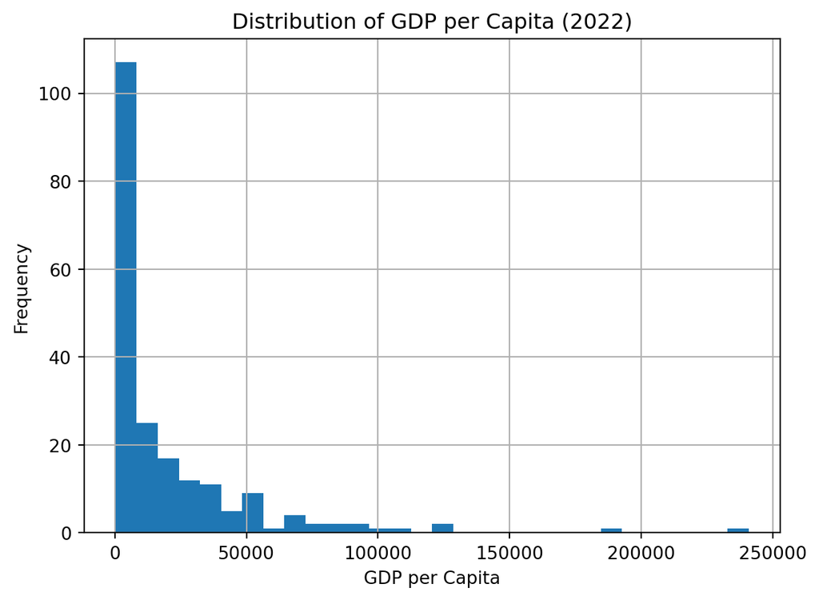

Figure 1: Distribution of GDP per capita across countries in 2022 (World Bank, 2022).

```python
# Histogram
plt.figure()
wdi["gdp_per_capita"].dropna().hist(bins=30)
plt.xlabel("GDP per Capita")
plt.ylabel("Frequency")
plt.title("Distribution of GDP per Capita (2022)")
plt.show()
```

Finding 1

As shown in Figure 1, GDP per capita is highly right-skewed. Most countries cluster at lower income levels, while a small number of countries exhibit extremely high income values. The long right tail confirms substantial global income inequality.

### 3.2 2. Inflation Rate

```python
wdi["inflation_rate"].describe()
```

```
count    169.000000
mean      12.493936
std       19.682433
min       -6.687321
25%        5.518129
50%        7.967574
75%       11.665567
max      171.205491
Name: inflation_rate, dtype: float64
```

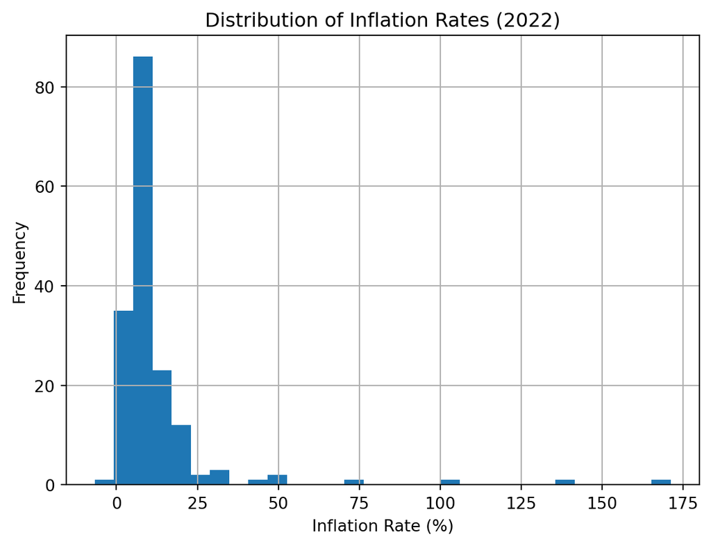

Figure 2: Distribution of inflation rates across countries in 2022 (World Bank, 2022).

```python
plt.figure()
wdi["inflation_rate"].dropna().hist(bins=30)
plt.xlabel("Inflation Rate (%)")
plt.ylabel("Frequency")
plt.title("Distribution of Inflation Rates (2022)")
plt.show()
```

Finding 2

Figure Figure 2 shows that most countries experienced inflation between 0% and 20% in 2022. However, several extreme outliers generate a long right tail. The difference between the median and maximum values indicates strong dispersion in inflation outcomes.

### 3.3 3. GDP Growth Rate

```python
wdi["gdp_growth_rate"].describe()
```

```
count    202.000000
mean       4.368901
std        6.626811
min      -28.758591
25%        2.438593
50%        4.204431
75%        6.200000
max       63.439864
Name: gdp_growth_rate, dtype: float64
```

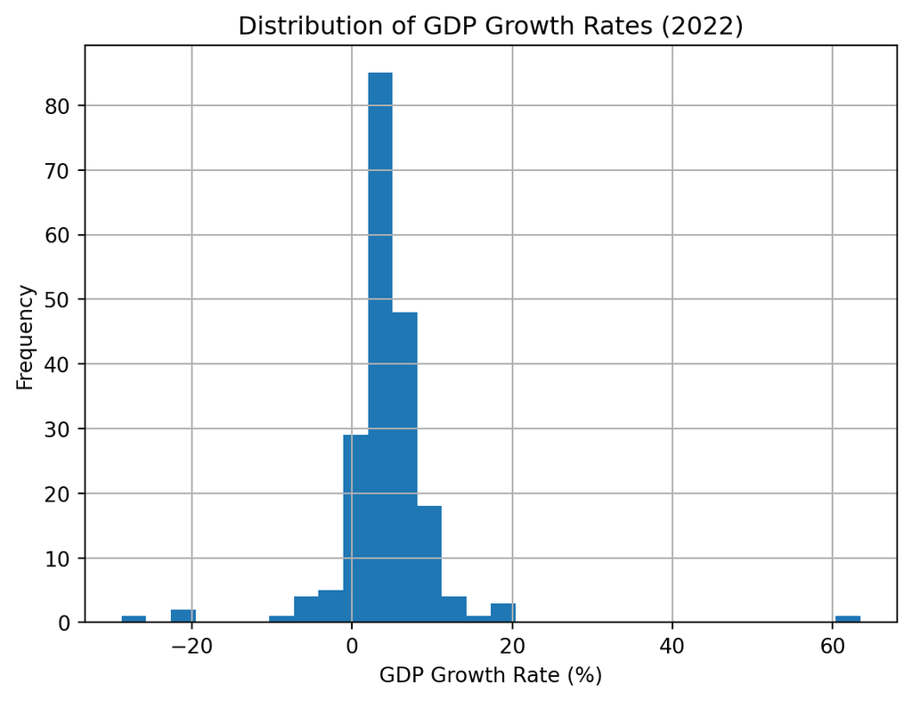

Figure 3: Distribution of GDP growth rates across countries in 2022 (World Bank, 2022).

```python
plt.figure()
wdi["gdp_growth_rate"].dropna().hist(bins=30)
plt.xlabel("GDP Growth Rate (%)")
plt.ylabel("Frequency")
plt.title("Distribution of GDP Growth Rates (2022)")
plt.show()
```

Finding 3

As illustrated in Figure 3, most countries recorded moderate GDP growth between 0% and 10%. A few countries experienced economic contraction, while one extreme outlier exceeds 60%, creating dispersion on both tails of the distribution.

Overall Observations

- Economic indicators show substantial cross-country heterogeneity.
- Income levels are highly unequal.
- Inflation and growth rates show large dispersion, likely influenced by global macroeconomic conditions in 2022.

## 4 Visualisations

Data source: World Bank, *World Development Indicators* (WDI), 2022 sample dataset provided in course repository.

### 4.1 Plot 1: Scatter Plot (GDP per Capita vs Inflation)

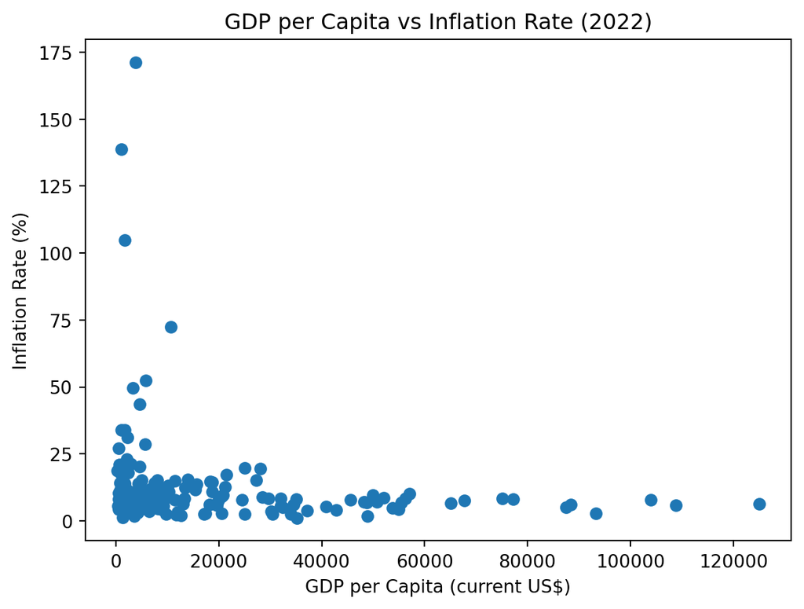

Figure 4: Relationship between GDP per capita and inflation (WDI, 2022).

As shown in Figure 4, there is no clear linear relationship between GDP per capita and inflation in 2022. While some high-income countries experienced moderate inflation, inflation rates vary widely across income levels.

### 4.2 Plot 2: Bar Chart (Top 10 Countries by GDP per Capita)

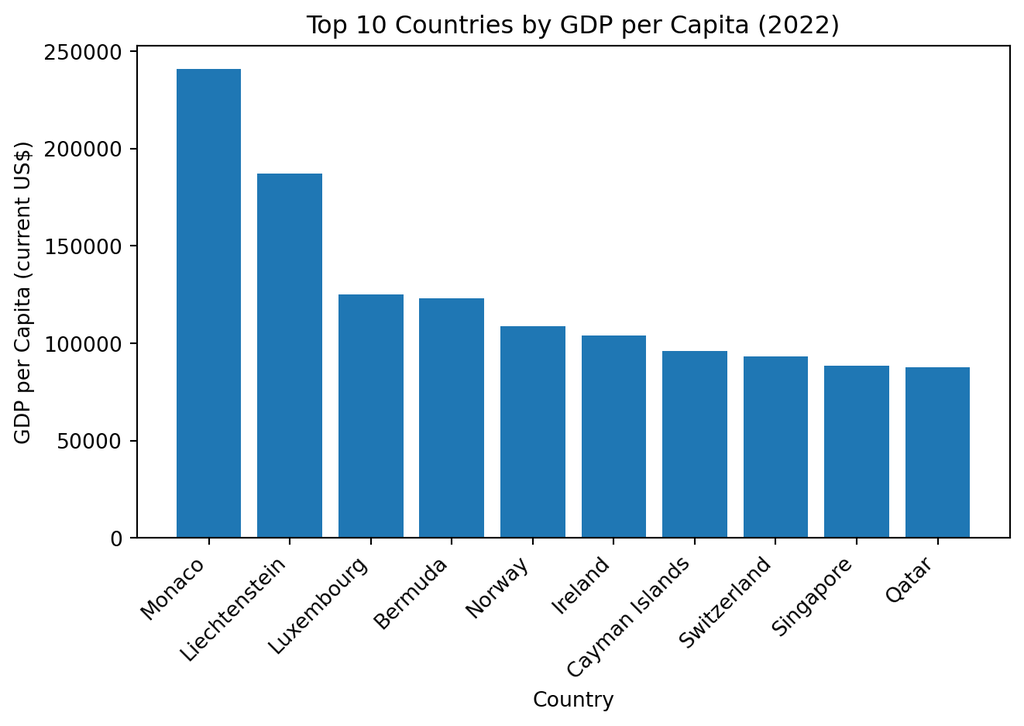

Figure 5: Top 10 countries by GDP per capita in 2022.

Figure Figure 5 highlights the top 10 countries by GDP per capita. The large gap between these countries and the rest of the sample helps explain the strong right-skew observed in the distribution of GDP per capita.

Notes

- The scatter plot helps assess whether higher-income countries tend to experience higher or lower inflation in 2022.
- The bar chart highlights the strongest outliers in GDP per capita and provides context for why the GDP-per-capita distribution is highly right-skewed.

## 5 Summary Table of Key Statistics

Table 1: Summary statistics for selected economic indicators (WDI, 2022). Source: World Bank, World Development Indicators.

|  | gdp_per_capita | inflation_rate | gdp_growth_rate |
| --- | --- | --- | --- |
| Count | 203.000000 | 169.000000 | 202.000000 |
| Mean | 20345.707649 | 12.493936 | 4.368901 |
| Median | 7587.588173 | 7.967574 | 4.204431 |
| Standard Deviation | 31308.942225 | 19.682433 | 6.626811 |
| Minimum | 259.025031 | -6.687321 | -28.758591 |
| Maximum | 240862.182448 | 171.205491 | 63.439864 |

*Source: World Bank, World Development Indicators (2022).*

The descriptive statistics reported in Table 1 show that GDP per capita exhibits substantial dispersion, with a large difference between the median and the maximum value. Similarly, inflation and growth rates display considerable cross-country variation.

## 6 References

Fischer, S. (1993). The role of macroeconomic factors in growth. *Journal of Monetary Economics*, *32*(3), 485–512.

World Bank. (2022). *World development indicators*. https://databank.worldbank.org/source/world-development-indicators